# Project: Data Analysis on tmdb-movies.csv

- Introduction
- Data Wrangling
- Exploratory Data Analysis
- Conclusions

## Introduction

> For this project, I have chosen the **tmdb-movies** dataset for data analysis. My personal interest towards movies is one of the main reasons for choosing this dataset. In this project, I would like to explore how the popularity of top genres has evolved over the years.

```python
# importing required packages
import pandas as pd
import numpy as np
import seaborn as sns
import matplotlib.pyplot as plt

%matplotlib inline
```

## Data Wrangling

### Assesing the data

In this section, we'll assess the data from different perspectives and arrive at an action-item list to clean the data in the next section

```python
df = pd.read_csv('tmdb-movies.csv')
df.shape
```

```
(10866, 21)
```

There are 10866 entries and 21 columns in the datase. Let us check what these columns are below.

```python
#finding information about the dataset
df.info()
```

```
<class 'pandas.core.frame.DataFrame'>
RangeIndex: 10866 entries, 0 to 10865
Data columns (total 21 columns):
 #   Column                Non-Null Count  Dtype
---  ------                --------------  -----
 0   id                    10866 non-null  int64
 1   imdb_id               10856 non-null  object
 2   popularity            10866 non-null  float64
 3   budget                10866 non-null  int64
 4   revenue               10866 non-null  int64
 5   original_title        10866 non-null  object
 6   cast                  10790 non-null  object
 7   homepage              2936 non-null   object
 8   director              10822 non-null  object
 9   tagline               8042 non-null   object
 10  keywords              9373 non-null   object
 11  overview              10862 non-null  object
 12  runtime               10866 non-null  int64
 13  genres                10843 non-null  object
 14  production_companies  9836 non-null   object
 15  release_date          10866 non-null  object
 16  vote_count            10866 non-null  int64
 17  vote_average          10866 non-null  float64
 18  release_year          10866 non-null  int64
 19  budget_adj            10866 non-null  float64
 20  revenue_adj           10866 non-null  float64
dtypes: float64(4), int64(6), object(11)
memory usage: 1.3+ MB
```

```python
#printing first ten data values
df.head()
```

|  | id | imdb_id | popularity | budget | revenue | original_title | cast | homepage | director | tagline | ... | overview | runtime | genres | production_companies | release_date | vote_count | vote_average | release_year | budget_adj | revenue_adj |
| --- | --- | --- | --- | --- | --- | --- | --- | --- | --- | --- | --- | --- | --- | --- | --- | --- | --- | --- | --- | --- | --- |
| 0 | 135397 | tt0369610 | 32.985763 | 150000000 | 1513528810 | Jurassic World | Chris Pratt\|Bryce Dallas Howard\|Irrfan Khan\|Vi... | http://www.jurassicworld.com/ | Colin Trevorrow | The park is open. | ... | Twenty-two years after the events of Jurassic ... | 124 | Action\|Adventure\|Science Fiction\|Thriller | Universal Studios\|Amblin Entertainment\|Legenda... | 6/9/15 | 5562 | 6.5 | 2015 | 1.379999e+08 | 1.392446e+09 |
| 1 | 76341 | tt1392190 | 28.419936 | 150000000 | 378436354 | Mad Max: Fury Road | Tom Hardy\|Charlize Theron\|Hugh Keays-Byrne\|Nic... | http://www.madmaxmovie.com/ | George Miller | What a Lovely Day. | ... | An apocalyptic story set in the furthest reach... | 120 | Action\|Adventure\|Science Fiction\|Thriller | Village Roadshow Pictures\|Kennedy Miller Produ... | 5/13/15 | 6185 | 7.1 | 2015 | 1.379999e+08 | 3.481613e+08 |
| 2 | 262500 | tt2908446 | 13.112507 | 110000000 | 295238201 | Insurgent | Shailene Woodley\|Theo James\|Kate Winslet\|Ansel... | http://www.thedivergentseries.movie/#insurgent | Robert Schwentke | One Choice Can Destroy You | ... | Beatrice Prior must confront her inner demons ... | 119 | Adventure\|Science Fiction\|Thriller | Summit Entertainment\|Mandeville Films\|Red Wago... | 3/18/15 | 2480 | 6.3 | 2015 | 1.012000e+08 | 2.716190e+08 |
| 3 | 140607 | tt2488496 | 11.173104 | 200000000 | 2068178225 | Star Wars: The Force Awakens | Harrison Ford\|Mark Hamill\|Carrie Fisher\|Adam D... | http://www.starwars.com/films/star-wars-episod... | J.J. Abrams | Every generation has a story. | ... | Thirty years after defeating the Galactic Empi... | 136 | Action\|Adventure\|Science Fiction\|Fantasy | Lucasfilm\|Truenorth Productions\|Bad Robot | 12/15/15 | 5292 | 7.5 | 2015 | 1.839999e+08 | 1.902723e+09 |
| 4 | 168259 | tt2820852 | 9.335014 | 190000000 | 1506249360 | Furious 7 | Vin Diesel\|Paul Walker\|Jason Statham\|Michelle ... | http://www.furious7.com/ | James Wan | Vengeance Hits Home | ... | Deckard Shaw seeks revenge against Dominic Tor... | 137 | Action\|Crime\|Thriller | Universal Pictures\|Original Film\|Media Rights ... | 4/1/15 | 2947 | 7.3 | 2015 | 1.747999e+08 | 1.385749e+09 |

5 rows × 21 columns

Columns such as *id, imdb_id, original_title, homepage, tagline, keywords, overview* are very specific to the movies. Since what we are trying to find is generic, we need to remove these fields. Also features such as *budget_adj and revenue_adj* can be removed since they are represented in US money in 2010. Let us add these as action points (1) and (2) to the action-item list.

```python
#checking if each column is of appropriate datatype
for column in df.columns:
    print('datatype of {} is'.format(column), type(df[column][0]))
```

```
datatype of id is <class 'numpy.int64'>
datatype of imdb_id is <class 'str'>
datatype of popularity is <class 'numpy.float64'>
datatype of budget is <class 'numpy.int64'>
datatype of revenue is <class 'numpy.int64'>
datatype of original_title is <class 'str'>
datatype of cast is <class 'str'>
datatype of homepage is <class 'str'>
datatype of director is <class 'str'>
datatype of tagline is <class 'str'>
datatype of keywords is <class 'str'>
datatype of overview is <class 'str'>
datatype of runtime is <class 'numpy.int64'>
datatype of genres is <class 'str'>
datatype of production_companies is <class 'str'>
datatype of release_date is <class 'str'>
datatype of vote_count is <class 'numpy.int64'>
datatype of vote_average is <class 'numpy.float64'>
datatype of release_year is <class 'numpy.int64'>
datatype of budget_adj is <class 'numpy.float64'>
datatype of revenue_adj is <class 'numpy.float64'>
```

```python
#checking for duplicate entries
sum(df.duplicated())
```

```
1
```

There seems to be one duplicate row in the data set that needs to be removed. Thus added as (3) in action-item list

```python
#checking missing values for each feature
for column in df.columns:
    print('Number of missing values for feature {} is'.format(column), sum(df[column].isnull()))
```

```
Number of missing values for feature id is 0
Number of missing values for feature imdb_id is 10
Number of missing values for feature popularity is 0
Number of missing values for feature budget is 0
Number of missing values for feature revenue is 0
Number of missing values for feature original_title is 0
Number of missing values for feature cast is 76
Number of missing values for feature homepage is 7930
Number of missing values for feature director is 44
Number of missing values for feature tagline is 2824
Number of missing values for feature keywords is 1493
Number of missing values for feature overview is 4
Number of missing values for feature runtime is 0
Number of missing values for feature genres is 23
Number of missing values for feature production_companies is 1030
Number of missing values for feature release_date is 0
Number of missing values for feature vote_count is 0
Number of missing values for feature vote_average is 0
Number of missing values for feature release_year is 0
Number of missing values for feature budget_adj is 0
Number of missing values for feature revenue_adj is 0
```

From the above print statements, it is clear that there are null entries that needs to be removed. Hence adding as action point (4)

```python
#performing basic statistical analysis of the data set
df.describe()
```

|  | id | popularity | budget | revenue | runtime | vote_count | vote_average | release_year | budget_adj | revenue_adj |
| --- | --- | --- | --- | --- | --- | --- | --- | --- | --- | --- |
| count | 10866.000000 | 10866.000000 | 1.086600e+04 | 1.086600e+04 | 10866.000000 | 10866.000000 | 10866.000000 | 10866.000000 | 1.086600e+04 | 1.086600e+04 |
| mean | 66064.177434 | 0.646441 | 1.462570e+07 | 3.982332e+07 | 102.070863 | 217.389748 | 5.974922 | 2001.322658 | 1.755104e+07 | 5.136436e+07 |
| std | 92130.136561 | 1.000185 | 3.091321e+07 | 1.170035e+08 | 31.381405 | 575.619058 | 0.935142 | 12.812941 | 3.430616e+07 | 1.446325e+08 |
| min | 5.000000 | 0.000065 | 0.000000e+00 | 0.000000e+00 | 0.000000 | 10.000000 | 1.500000 | 1960.000000 | 0.000000e+00 | 0.000000e+00 |
| 25% | 10596.250000 | 0.207583 | 0.000000e+00 | 0.000000e+00 | 90.000000 | 17.000000 | 5.400000 | 1995.000000 | 0.000000e+00 | 0.000000e+00 |
| 50% | 20669.000000 | 0.383856 | 0.000000e+00 | 0.000000e+00 | 99.000000 | 38.000000 | 6.000000 | 2006.000000 | 0.000000e+00 | 0.000000e+00 |
| 75% | 75610.000000 | 0.713817 | 1.500000e+07 | 2.400000e+07 | 111.000000 | 145.750000 | 6.600000 | 2011.000000 | 2.085325e+07 | 3.369710e+07 |
| max | 417859.000000 | 32.985763 | 4.250000e+08 | 2.781506e+09 | 900.000000 | 9767.000000 | 9.200000 | 2015.000000 | 4.250000e+08 | 2.827124e+09 |

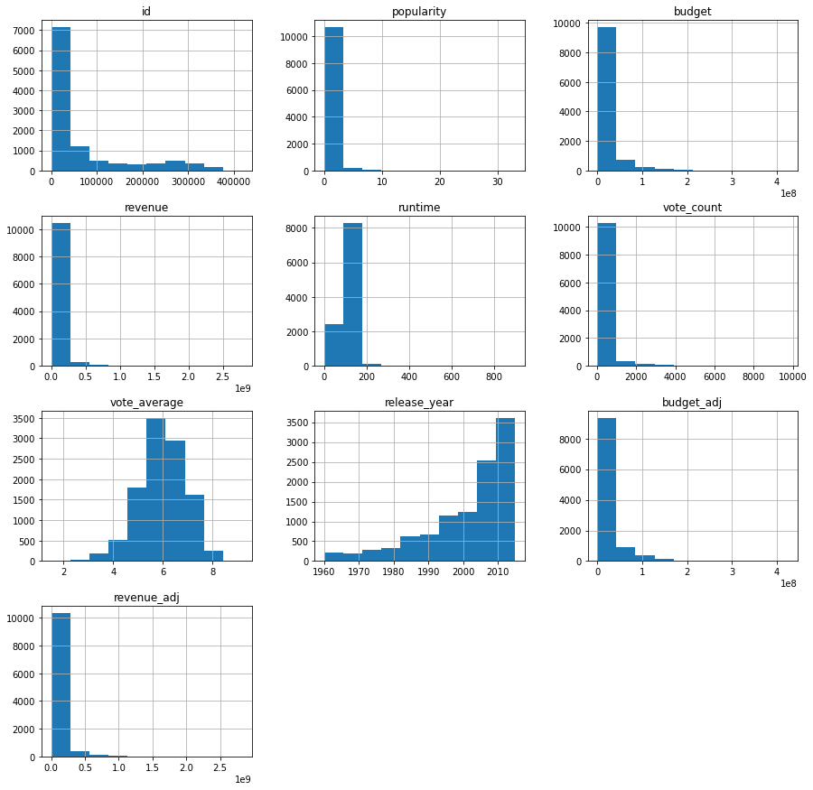

```python
df.hist(figsize=(15,15));
```

From the above histogram plots, we can find that:

1. Features such as popularity, budget, revenue, vote_count, budget_adj, revenue_adj are right skewed. This means that there are very few number of movies spending in billions or making a profit in billions.
2. release_year is left skewed which means more number of movies have be released in the recent years as compared to the past

### Cleaning actions that needs to be done

1. Filter the data by removing fields 'id', 'imdb_id', 'original_title', 'homepage', 'tagline', 'keywords', 'overview' from the table
2. Remove the fields 'budget_adj' and 'revenue_adj' from the table
3. Remove the single duplicate entry
4. Remove the rows with null values

### Data Cleaning (Let us start cleaning the data by following the above list)

#### 1. Filtering the data

```python
# removing fields 'id', 'imdb_id', 'original_title', 'homepage', 'tagline', 'keywords', 'overview' from the table
df.drop(['id', 'imdb_id', 'original_title', 'homepage', 'tagline', 'keywords', 'overview'],axis='columns', inplace=True)
```

```python
#rechecking if feilds are removed --  7 columns:
#'id', 'imdb_id', 'original_title', 'homepage', 'tagline', 'keywords', 'overview' must not be present
df.info()
```

```
<class 'pandas.core.frame.DataFrame'>
RangeIndex: 10866 entries, 0 to 10865
Data columns (total 14 columns):
 #   Column                Non-Null Count  Dtype
---  ------                --------------  -----
 0   popularity            10866 non-null  float64
 1   budget                10866 non-null  int64
 2   revenue               10866 non-null  int64
 3   cast                  10790 non-null  object
 4   director              10822 non-null  object
 5   runtime               10866 non-null  int64
 6   genres                10843 non-null  object
 7   production_companies  9836 non-null   object
 8   release_date          10866 non-null  object
 9   vote_count            10866 non-null  int64
 10  vote_average          10866 non-null  float64
 11  release_year          10866 non-null  int64
 12  budget_adj            10866 non-null  float64
 13  revenue_adj           10866 non-null  float64
dtypes: float64(4), int64(5), object(5)
memory usage: 976.3+ KB
```

#### 2. Remove the fields 'budget_adj' and 'revenue_adj' from the table

```python
#removing the fields 'budget_adj' and 'revenue_adj'
df.drop(['budget_adj','revenue_adj'], axis='columns', inplace=True)
```

```python
#rechecking if feilds are removed -- budget-adj and revenue_adg must not be present
df.info()
```

```
<class 'pandas.core.frame.DataFrame'>
RangeIndex: 10866 entries, 0 to 10865
Data columns (total 12 columns):
 #   Column                Non-Null Count  Dtype
---  ------                --------------  -----
 0   popularity            10866 non-null  float64
 1   budget                10866 non-null  int64
 2   revenue               10866 non-null  int64
 3   cast                  10790 non-null  object
 4   director              10822 non-null  object
 5   runtime               10866 non-null  int64
 6   genres                10843 non-null  object
 7   production_companies  9836 non-null   object
 8   release_date          10866 non-null  object
 9   vote_count            10866 non-null  int64
 10  vote_average          10866 non-null  float64
 11  release_year          10866 non-null  int64
dtypes: float64(2), int64(5), object(5)
memory usage: 806.5+ KB
```

#### 3. Remove the duplicated entry

```python
#rechecking if duplicated entry is present after the above cleaning operation
df.duplicated().sum()
```

```
1
```

```python
#removing duplicated entry
df.drop_duplicates(inplace=True)
```

```python
#cheking if duplicates are dropped -- sum must return 0
df.duplicated().sum()
```

```
0
```

#### 4. Drop the rows with null values

```python
df.dropna(inplace=True)
```

```python
#check if any of the columns in the dataset have null value --must return False
df.isnull().sum().any()
```

```
False
```

```python
df.info()
```

```
<class 'pandas.core.frame.DataFrame'>
Int64Index: 9772 entries, 0 to 10865
Data columns (total 12 columns):
 #   Column                Non-Null Count  Dtype
---  ------                --------------  -----
 0   popularity            9772 non-null   float64
 1   budget                9772 non-null   int64
 2   revenue               9772 non-null   int64
 3   cast                  9772 non-null   object
 4   director              9772 non-null   object
 5   runtime               9772 non-null   int64
 6   genres                9772 non-null   object
 7   production_companies  9772 non-null   object
 8   release_date          9772 non-null   object
 9   vote_count            9772 non-null   int64
 10  vote_average          9772 non-null   float64
 11  release_year          9772 non-null   int64
dtypes: float64(2), int64(5), object(5)
memory usage: 801.6+ KB
```

```python
#resetting the index
df.reset_index(inplace=True)
```

```python
#rechecking if index has been reset -- index range must be from 0 to 9771
df.info()
```

```
<class 'pandas.core.frame.DataFrame'>
RangeIndex: 9772 entries, 0 to 9771
Data columns (total 13 columns):
 #   Column                Non-Null Count  Dtype
---  ------                --------------  -----
 0   index                 9772 non-null   int64
 1   popularity            9772 non-null   float64
 2   budget                9772 non-null   int64
 3   revenue               9772 non-null   int64
 4   cast                  9772 non-null   object
 5   director              9772 non-null   object
 6   runtime               9772 non-null   int64
 7   genres                9772 non-null   object
 8   production_companies  9772 non-null   object
 9   release_date          9772 non-null   object
 10  vote_count            9772 non-null   int64
 11  vote_average          9772 non-null   float64
 12  release_year          9772 non-null   int64
dtypes: float64(2), int64(6), object(5)
memory usage: 801.7+ KB
```

## Exploratory Data Analysis

### Research Question 1 (Popularity of top genres from each year to year)

#### For this analysis we'll be concentrating on two independent variables(genre, year) and one dependent variable(popularity)

```python
#let's have a look at the first five entries of these variables
print(df['release_year'][:5])
print(df['genres'][:5])
print(df['popularity'][:5])
```

```
0    2015
1    2015
2    2015
3    2015
4    2015
Name: release_year, dtype: int64
0    Action|Adventure|Science Fiction|Thriller
1    Action|Adventure|Science Fiction|Thriller
2           Adventure|Science Fiction|Thriller
3     Action|Adventure|Science Fiction|Fantasy
4                        Action|Crime|Thriller
Name: genres, dtype: object
0    32.985763
1    28.419936
2    13.112507
3    11.173104
4     9.335014
Name: popularity, dtype: float64
```

#### The release year and popularity seems to be fitting for further data analysis. But each row in genres belong to multiple categories. Hence we need to do some wrangling here.

```python
#creating another column 'genres_corrected' that will have genres in lower case and space replaced by underscore
df['genres_corrected'] = pd.Series(dtype=str)
```

```python
#going through each entries in genres, then converting them to lower case and replacing ' ' with '_'
for index, genre in enumerate(df.genres):
    df['genres_corrected'].iloc[index] = '|'.join([each.strip().lower().replace(' ', '_')  for each in genre.split('|')])
```

```python
#checking if there's any null value present in the dataframe after the above operation -- must return False
df.isnull().sum().any()
```

```
False
```

```python
#checking for corrected genre format for first three, 3 random middle and last three entries.
df.head(3)
```

|  | index | popularity | budget | revenue | cast | director | runtime | genres | production_companies | release_date | vote_count | vote_average | release_year | genres_corrected |
| --- | --- | --- | --- | --- | --- | --- | --- | --- | --- | --- | --- | --- | --- | --- |
| 0 | 0 | 32.985763 | 150000000 | 1513528810 | Chris Pratt\|Bryce Dallas Howard\|Irrfan Khan\|Vi... | Colin Trevorrow | 124 | Action\|Adventure\|Science Fiction\|Thriller | Universal Studios\|Amblin Entertainment\|Legenda... | 6/9/15 | 5562 | 6.5 | 2015 | action\|adventure\|science_fiction\|thriller |
| 1 | 1 | 28.419936 | 150000000 | 378436354 | Tom Hardy\|Charlize Theron\|Hugh Keays-Byrne\|Nic... | George Miller | 120 | Action\|Adventure\|Science Fiction\|Thriller | Village Roadshow Pictures\|Kennedy Miller Produ... | 5/13/15 | 6185 | 7.1 | 2015 | action\|adventure\|science_fiction\|thriller |
| 2 | 2 | 13.112507 | 110000000 | 295238201 | Shailene Woodley\|Theo James\|Kate Winslet\|Ansel... | Robert Schwentke | 119 | Adventure\|Science Fiction\|Thriller | Summit Entertainment\|Mandeville Films\|Red Wago... | 3/18/15 | 2480 | 6.3 | 2015 | adventure\|science_fiction\|thriller |

```python
#checking for random middle entries
df.iloc[577:580]
```

|  | index | popularity | budget | revenue | cast | director | runtime | genres | production_companies | release_date | vote_count | vote_average | release_year | genres_corrected |
| --- | --- | --- | --- | --- | --- | --- | --- | --- | --- | --- | --- | --- | --- | --- |
| 577 | 648 | 4.983782 | 210000000 | 245500000 | Mark Wahlberg\|Stanley Tucci\|Nicola Peltz\|Jack ... | Michael Bay | 165 | Science Fiction\|Action\|Adventure | Paramount Pictures\|Amblin Entertainment\|Di Bon... | 6/25/14 | 2161 | 5.9 | 2014 | science_fiction\|action\|adventure |
| 578 | 649 | 4.930820 | 30000000 | 174600318 | Ralph Fiennes\|Tony Revolori\|F. Murray Abraham\|... | Wes Anderson | 99 | Comedy\|Drama | Fox Searchlight Pictures\|Scott Rudin Productio... | 2/26/14 | 2802 | 7.9 | 2014 | comedy\|drama |
| 579 | 650 | 4.780419 | 3300000 | 13993093 | Miles Teller\|J.K. Simmons\|Melissa Benoist\|Aust... | Damien Chazelle | 105 | Drama\|Music | Bold Films\|Blumhouse Productions\|Right of Way ... | 10/10/14 | 2372 | 8.2 | 2014 | drama\|music |

```python
#checking for the last three entries
df.tail(3)
```

|  | index | popularity | budget | revenue | cast | director | runtime | genres | production_companies | release_date | vote_count | vote_average | release_year | genres_corrected |
| --- | --- | --- | --- | --- | --- | --- | --- | --- | --- | --- | --- | --- | --- | --- |
| 9769 | 10863 | 0.065141 | 0 | 0 | Innokentiy Smoktunovskiy\|Oleg Efremov\|Georgi Z... | Eldar Ryazanov | 94 | Mystery\|Comedy | Mosfilm | 1/1/66 | 11 | 6.5 | 1966 | mystery\|comedy |
| 9770 | 10864 | 0.064317 | 0 | 0 | Tatsuya Mihashi\|Akiko Wakabayashi\|Mie Hama\|Joh... | Woody Allen | 80 | Action\|Comedy | Benedict Pictures Corp. | 11/2/66 | 22 | 5.4 | 1966 | action\|comedy |
| 9771 | 10865 | 0.035919 | 19000 | 0 | Harold P. Warren\|Tom Neyman\|John Reynolds\|Dian... | Harold P. Warren | 74 | Horror | Norm-Iris | 11/15/66 | 15 | 1.5 | 1966 | horror |

Each movie in the data frame belongs to multiple genres. Hence we'll create an indicator data frame by following the below methods.

1. Find out all the unique genres present in the data
2. Create an initial indicator data frame of (shape= len(main_data), len(all_unique_genres)) will all entries as zeros
3. Go through each corrected genre entry in the data frame and for each genre, add entry as 1 in the corresponding genre column in the indicator data frame
4. Join the indicator_df with the main data frame

```python
#1. finding all the genres in data table
genres_all = (set(genre.split('|')) for genre in df.genres_corrected)
```

```python
genres = set.union(*genres_all)
```

```python
genres
```

```
{'action',
 'adventure',
 'animation',
 'comedy',
 'crime',
 'documentary',
 'drama',
 'family',
 'fantasy',
 'foreign',
 'history',
 'horror',
 'music',
 'mystery',
 'romance',
 'science_fiction',
 'thriller',
 'tv_movie',
 'war',
 'western'}
```

```python
#2. Creating an indicator data frame with all zeros as default value
indicator_df = pd.DataFrame(np.zeros((df.shape[0], len(genres)), dtype='int'), columns=genres)
```

```python
#checking the shape of indicator data frame -- must be 9772,20
indicator_df.shape
```

```
(9772, 20)
```

```python
#3. Going through each corrected genre entry in the data frame and for each genre found, adding entry as 1
#in the corresponding genre column in the indicator data frame
for index, genre in enumerate(df.genres_corrected):
    indicator_df.loc[index, genre.split('|')] = 1
```

```python
indicator_df.head()
```

|  | action | family | animation | romance | horror | documentary | music | drama | fantasy | adventure | mystery | war | comedy | western | science_fiction | thriller | foreign | history | crime | tv_movie |
| --- | --- | --- | --- | --- | --- | --- | --- | --- | --- | --- | --- | --- | --- | --- | --- | --- | --- | --- | --- | --- |
| 0 | 1 | 0 | 0 | 0 | 0 | 0 | 0 | 0 | 0 | 1 | 0 | 0 | 0 | 0 | 1 | 1 | 0 | 0 | 0 | 0 |
| 1 | 1 | 0 | 0 | 0 | 0 | 0 | 0 | 0 | 0 | 1 | 0 | 0 | 0 | 0 | 1 | 1 | 0 | 0 | 0 | 0 |
| 2 | 0 | 0 | 0 | 0 | 0 | 0 | 0 | 0 | 0 | 1 | 0 | 0 | 0 | 0 | 1 | 1 | 0 | 0 | 0 | 0 |
| 3 | 1 | 0 | 0 | 0 | 0 | 0 | 0 | 0 | 1 | 1 | 0 | 0 | 0 | 0 | 1 | 0 | 0 | 0 | 0 | 0 |
| 4 | 1 | 0 | 0 | 0 | 0 | 0 | 0 | 0 | 0 | 0 | 0 | 0 | 0 | 0 | 0 | 1 | 0 | 0 | 1 | 0 |

```python
#checking first few corrected genre element with the indicator_df. The genres must be split and the corresponding columns in the indicator_df
#must have entries as 1
print(df.genres_corrected[0:3])
indicator_df.head(3)
```

```
0    action|adventure|science_fiction|thriller
1    action|adventure|science_fiction|thriller
2           adventure|science_fiction|thriller
Name: genres_corrected, dtype: object
```

|  | action | family | animation | romance | horror | documentary | music | drama | fantasy | adventure | mystery | war | comedy | western | science_fiction | thriller | foreign | history | crime | tv_movie |
| --- | --- | --- | --- | --- | --- | --- | --- | --- | --- | --- | --- | --- | --- | --- | --- | --- | --- | --- | --- | --- |
| 0 | 1 | 0 | 0 | 0 | 0 | 0 | 0 | 0 | 0 | 1 | 0 | 0 | 0 | 0 | 1 | 1 | 0 | 0 | 0 | 0 |
| 1 | 1 | 0 | 0 | 0 | 0 | 0 | 0 | 0 | 0 | 1 | 0 | 0 | 0 | 0 | 1 | 1 | 0 | 0 | 0 | 0 |
| 2 | 0 | 0 | 0 | 0 | 0 | 0 | 0 | 0 | 0 | 1 | 0 | 0 | 0 | 0 | 1 | 1 | 0 | 0 | 0 | 0 |

```python
#combining indicator_df with the original table df
df_genres = df.join(indicator_df.add_prefix('genre_'))
```

```python
#checking number of rows and columns of created dataframe -- must be 9772,34
df_genres.shape
```

```
(9772, 34)
```

```python
#checking for first two entries
df_genres.head(2)
```

|  | index | popularity | budget | revenue | cast | director | runtime | genres | production_companies | release_date | ... | genre_mystery | genre_war | genre_comedy | genre_western | genre_science_fiction | genre_thriller | genre_foreign | genre_history | genre_crime | genre_tv_movie |
| --- | --- | --- | --- | --- | --- | --- | --- | --- | --- | --- | --- | --- | --- | --- | --- | --- | --- | --- | --- | --- | --- |
| 0 | 0 | 32.985763 | 150000000 | 1513528810 | Chris Pratt\|Bryce Dallas Howard\|Irrfan Khan\|Vi... | Colin Trevorrow | 124 | Action\|Adventure\|Science Fiction\|Thriller | Universal Studios\|Amblin Entertainment\|Legenda... | 6/9/15 | ... | 0 | 0 | 0 | 0 | 1 | 1 | 0 | 0 | 0 | 0 |
| 1 | 1 | 28.419936 | 150000000 | 378436354 | Tom Hardy\|Charlize Theron\|Hugh Keays-Byrne\|Nic... | George Miller | 120 | Action\|Adventure\|Science Fiction\|Thriller | Village Roadshow Pictures\|Kennedy Miller Produ... | 5/13/15 | ... | 0 | 0 | 0 | 0 | 1 | 1 | 0 | 0 | 0 | 0 |

2 rows × 34 columns

```python
#checking for null values after the above join operation. -- all columns must have 9772 non-null objects
df_genres.info()
```

```
<class 'pandas.core.frame.DataFrame'>
RangeIndex: 9772 entries, 0 to 9771
Data columns (total 34 columns):
 #   Column                 Non-Null Count  Dtype
---  ------                 --------------  -----
 0   index                  9772 non-null   int64
 1   popularity             9772 non-null   float64
 2   budget                 9772 non-null   int64
 3   revenue                9772 non-null   int64
 4   cast                   9772 non-null   object
 5   director               9772 non-null   object
 6   runtime                9772 non-null   int64
 7   genres                 9772 non-null   object
 8   production_companies   9772 non-null   object
 9   release_date           9772 non-null   object
```

[output cut: 26 more lines]

#### Now that we have data set ready for our question.We try to get populariy for each genre for each year.

```python
def get_popularity_for_each_genre_by_year(genre_name):
    '''
    Input: genre name
    Function: Filters the data for the given genre, then groups the filtered data by release year and computes mean for
    popularity
    Output: returns the mean popularity for the input genre
    '''
    temp_series = df_genres.query('{} == 1'.format(genre_name))
    genre_popularity = temp_series.groupby('release_year')['popularity'].mean()
    genre_popularity.name = genre_name
    return genre_popularity
```

```python
# creating a new series and keeping appending mean popularity for each genre for every years to the series
genre_popularity = pd.Series(dtype=float)
for genre in genres:
    genre_popularity = pd.concat([genre_popularity,get_popularity_for_each_genre_by_year('genre_'+genre)], axis=1)
```

```python
#viewing first 3 elements
genre_popularity.head(3)
```

|  | 0 | genre_action | genre_family | genre_animation | genre_romance | genre_horror | genre_documentary | genre_music | genre_drama | genre_fantasy | ... | genre_mystery | genre_war | genre_comedy | genre_western | genre_science_fiction | genre_thriller | genre_foreign | genre_history | genre_crime | genre_tv_movie |
| --- | --- | --- | --- | --- | --- | --- | --- | --- | --- | --- | --- | --- | --- | --- | --- | --- | --- | --- | --- | --- | --- |
| 1960 | NaN | 0.590724 | 0.278064 | NaN | 0.541227 | 0.591450 | NaN | 0.423531 | 0.566305 | 0.428247 | ... | NaN | 0.225863 | 0.396000 | 0.567759 | 0.327905 | 0.811910 | 0.194948 | 0.412364 | 0.346479 | NaN |
| 1961 | NaN | 0.365913 | 0.896028 | 2.631987 | 0.426036 | 0.254578 | NaN | 0.564748 | 0.432233 | 0.113651 | ... | 0.712793 | 0.531184 | 0.679838 | 0.210021 | 0.300638 | NaN | 0.113651 | 0.334463 | 0.806519 | NaN |
| 1962 | NaN | 0.845972 | 0.323463 | NaN | 0.365621 | 0.179368 | NaN | 0.323933 | 0.401909 | 0.235542 | ... | 0.259220 | 0.700761 | 0.273183 | 0.414180 | 0.179212 | 0.760582 | 0.235542 | 0.640491 | 0.472816 | NaN |

3 rows × 21 columns

```python
#dropping any column that has all values as null
genre_popularity.dropna(how='all', axis='columns', inplace=True)
```

```python
#filling nan values with mean popularity of that genre
for column in genre_popularity.columns:
    genre_popularity[column].fillna(genre_popularity[column].mean(), inplace=True)
```

```python
#checking if the column0 with all nan values has been removed and if nan values are replaced with the mean values
genre_popularity.info()
```

```
<class 'pandas.core.frame.DataFrame'>
Index: 56 entries, 1960 to 2015
Data columns (total 20 columns):
 #   Column                 Non-Null Count  Dtype
---  ------                 --------------  -----
 0   genre_action           56 non-null     float64
 1   genre_family           56 non-null     float64
 2   genre_animation        56 non-null     float64
 3   genre_romance          56 non-null     float64
 4   genre_horror           56 non-null     float64
 5   genre_documentary      56 non-null     float64
 6   genre_music            56 non-null     float64
 7   genre_drama            56 non-null     float64
 8   genre_fantasy          56 non-null     float64
 9   genre_adventure        56 non-null     float64
 10  genre_mystery          56 non-null     float64
 11  genre_war              56 non-null     float64
 12  genre_comedy           56 non-null     float64
 13  genre_western          56 non-null     float64
 14  genre_science_fiction  56 non-null     float64
 15  genre_thriller         56 non-null     float64
 16  genre_foreign          56 non-null     float64
 17  genre_history          56 non-null     float64
 18  genre_crime            56 non-null     float64
 19  genre_tv_movie         56 non-null     float64
dtypes: float64(20)
memory usage: 9.0+ KB
```

```python
#verifying that all years data is present -- must return True
df_genres.release_year.nunique() == genre_popularity.shape[0]
```

```
True
```

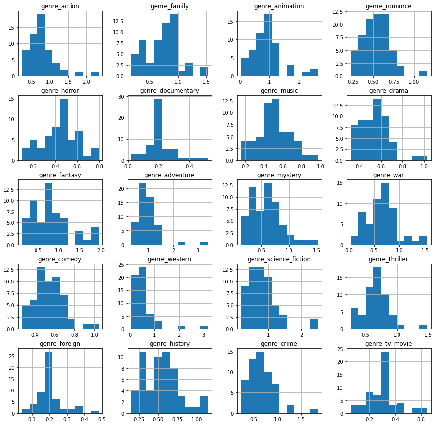

```python
#histograms for each genre
genre_popularity.hist(figsize=(15,15));
```

From the above histogram, we could find that genre_animation and genre_adventure has been more popular as compared to others

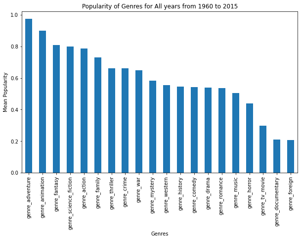

```python
#mean popularity for all the genres for all the years
genre_popularity.mean().sort_values(ascending=False).plot(kind='bar', figsize=(10,6))
plt.title('Popularity of Genres for All years from 1960 to 2015')
plt.xlabel('Genres')
plt.ylabel('Mean Popularity');
```

```python
#Displaying line chart for only the top 5 genres across years as displaying all the data made the chart messy
top5_genres = list(genre_popularity.mean().sort_values(ascending=False)[0:5].index)
top5_genres
```

```
['genre_adventure',
 'genre_animation',
 'genre_fantasy',
 'genre_science_fiction',
 'genre_action']
```

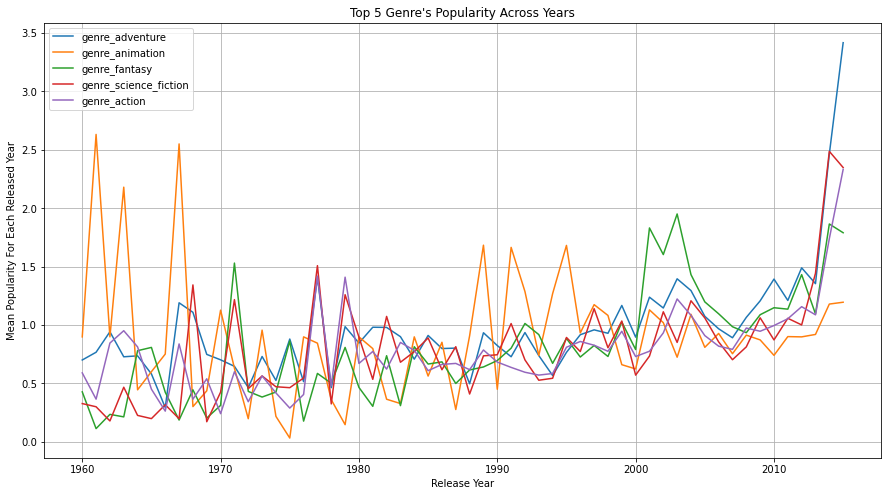

```python
genre_popularity[top5_genres].plot(kind='line', figsize=(15,8))
plt.title(r"Top 5 Genre's Popularity Across Years")
plt.xlabel('Release Year')
plt.ylabel('Mean Popularity For Each Released Year')
plt.grid()
plt.legend(loc='upper left');
```

## Conclusions

From the above analysis, it is clear that the most popular genre for the reported dataset is 'adventure'. If we consider the popularity across years for the top 5 genres, we could say that:

1. Animation was most popular in 1960's to 1970
2. From 1970's to 1980 many genres has been popular. Fantasy, science_fiction and action has made peaks in this region
3. Animation has made peak again in the late 1980's and early 1990's
4. Fantasy has been popular from 2000's to 2010
5. From 2010 onwards, adventure seeems to top the table

Above analysis is applicable only for the shared dataset- tmdb-movies.csv

Only basic statistics have been used to arrive at the above conclusions

The above findings are dervied from only a part of the dataset as many entries were removed due to missing data